# Risk Factor Analysis

## Outcome Variable

**Outcome Variable:** stunted

## Predictor Variables

**Intervention Variable:** predfeed3

**Adjustment Set:**

- arm
- sex
- month
- brthmon
- W_mage
- meducyrs
- feducyrs
- hhwealth_quart
- hfoodsec
- W_mhtcm
- W_mwtkg
- W_mbmi
- vagbrth
- W_gagebrth
- W_birthwt
- W_birthlen
- W_nrooms
- W_nchldlt5
- W_parity
- impfloor
- impsan
- safeh20
- delta_W_mage
- delta_meducyrs
- delta_feducyrs
- delta_hhwealth_quart
- delta_hfoodsec
- delta_W_mhtcm
- delta_W_mwtkg
- delta_W_mbmi
- delta_vagbrth
- delta_W_gagebrth
- delta_W_birthwt
- delta_W_birthlen
- delta_W_nrooms
- delta_W_nchldlt5
- delta_W_parity
- delta_impfloor
- delta_impsan
- delta_safeh20

## Stratifying Variables

The analysis was stratified on these variable(s):

- agecat
- studyid
- country

## Data Summary

| agecat | studyid | country | predfeed3 | stunted | n_cell | n |
| --- | --- | --- | --- | --- | --- | --- |
| Birth | ki0047075b-MAL-ED | BANGLADESH | 1 | 0 | 141 | 215 |
| Birth | ki0047075b-MAL-ED | BANGLADESH | 1 | 1 | 35 | 215 |
| Birth | ki0047075b-MAL-ED | BANGLADESH | 0 | 0 | 34 | 215 |
| Birth | ki0047075b-MAL-ED | BANGLADESH | 0 | 1 | 5 | 215 |
| Birth | ki0047075b-MAL-ED | BRAZIL | 1 | 0 | 21 | 57 |
| Birth | ki0047075b-MAL-ED | BRAZIL | 1 | 1 | 3 | 57 |
| Birth | ki0047075b-MAL-ED | BRAZIL | 0 | 0 | 28 | 57 |
| Birth | ki0047075b-MAL-ED | BRAZIL | 0 | 1 | 5 | 57 |
| Birth | ki0047075b-MAL-ED | INDIA | 1 | 0 | 21 | 41 |
| Birth | ki0047075b-MAL-ED | INDIA | 1 | 1 | 8 | 41 |
| Birth | ki0047075b-MAL-ED | INDIA | 0 | 0 | 12 | 41 |
| Birth | ki0047075b-MAL-ED | INDIA | 0 | 1 | 0 | 41 |
| Birth | ki0047075b-MAL-ED | NEPAL | 1 | 0 | 13 | 26 |
| Birth | ki0047075b-MAL-ED | NEPAL | 1 | 1 | 1 | 26 |
| Birth | ki0047075b-MAL-ED | NEPAL | 0 | 0 | 11 | 26 |
| Birth | ki0047075b-MAL-ED | NEPAL | 0 | 1 | 1 | 26 |
| Birth | ki0047075b-MAL-ED | PERU | 1 | 0 | 134 | 223 |
| Birth | ki0047075b-MAL-ED | PERU | 1 | 1 | 16 | 223 |
| Birth | ki0047075b-MAL-ED | PERU | 0 | 0 | 65 | 223 |
| Birth | ki0047075b-MAL-ED | PERU | 0 | 1 | 8 | 223 |
| Birth | ki0047075b-MAL-ED | SOUTH AFRICA | 1 | 0 | 32 | 100 |
| Birth | ki0047075b-MAL-ED | SOUTH AFRICA | 1 | 1 | 1 | 100 |
| Birth | ki0047075b-MAL-ED | SOUTH AFRICA | 0 | 0 | 59 | 100 |
| Birth | ki0047075b-MAL-ED | SOUTH AFRICA | 0 | 1 | 8 | 100 |
| Birth | ki0047075b-MAL-ED | TANZANIA, UNITED REPUBLIC OF | 1 | 0 | 21 | 102 |
| Birth | ki0047075b-MAL-ED | TANZANIA, UNITED REPUBLIC OF | 1 | 1 | 5 | 102 |
| Birth | ki0047075b-MAL-ED | TANZANIA, UNITED REPUBLIC OF | 0 | 0 | 62 | 102 |
| Birth | ki0047075b-MAL-ED | TANZANIA, UNITED REPUBLIC OF | 0 | 1 | 14 | 102 |
| Birth | ki1000109-EE | PAKISTAN | 1 | 0 | 20 | 35 |
| Birth | ki1000109-EE | PAKISTAN | 1 | 1 | 15 | 35 |

[output cut: 102 more lines]

The following strata were considered:

- agecat: 24 months, studyid: ki0047075b-MAL-ED, country: BANGLADESH
- agecat: 24 months, studyid: ki0047075b-MAL-ED, country: BRAZIL
- agecat: 24 months, studyid: ki0047075b-MAL-ED, country: INDIA
- agecat: 24 months, studyid: ki0047075b-MAL-ED, country: NEPAL
- agecat: 24 months, studyid: ki0047075b-MAL-ED, country: PERU
- agecat: 24 months, studyid: ki0047075b-MAL-ED, country: SOUTH AFRICA
- agecat: 24 months, studyid: ki0047075b-MAL-ED, country: TANZANIA, UNITED REPUBLIC OF
- agecat: 24 months, studyid: ki1000109-EE, country: PAKISTAN
- agecat: 24 months, studyid: ki1113344-GMS-Nepal, country: NEPAL
- agecat: 24 months, studyid: kiGH5241-JiVitA-3, country: BANGLADESH
- agecat: 24 months, studyid: kiGH5241-JiVitA-4, country: BANGLADESH
- agecat: 6 months, studyid: ki0047075b-MAL-ED, country: BANGLADESH
- agecat: 6 months, studyid: ki0047075b-MAL-ED, country: BRAZIL
- agecat: 6 months, studyid: ki0047075b-MAL-ED, country: INDIA
- agecat: 6 months, studyid: ki0047075b-MAL-ED, country: NEPAL
- agecat: 6 months, studyid: ki0047075b-MAL-ED, country: PERU
- agecat: 6 months, studyid: ki0047075b-MAL-ED, country: SOUTH AFRICA
- agecat: 6 months, studyid: ki0047075b-MAL-ED, country: TANZANIA, UNITED REPUBLIC OF
- agecat: 6 months, studyid: ki1000109-EE, country: PAKISTAN
- agecat: 6 months, studyid: ki1113344-GMS-Nepal, country: NEPAL
- agecat: 6 months, studyid: kiGH5241-JiVitA-3, country: BANGLADESH
- agecat: 6 months, studyid: kiGH5241-JiVitA-4, country: BANGLADESH
- agecat: Birth, studyid: ki0047075b-MAL-ED, country: BANGLADESH
- agecat: Birth, studyid: ki0047075b-MAL-ED, country: BRAZIL
- agecat: Birth, studyid: ki0047075b-MAL-ED, country: INDIA
- agecat: Birth, studyid: ki0047075b-MAL-ED, country: NEPAL
- agecat: Birth, studyid: ki0047075b-MAL-ED, country: PERU
- agecat: Birth, studyid: ki0047075b-MAL-ED, country: SOUTH AFRICA
- agecat: Birth, studyid: ki0047075b-MAL-ED, country: TANZANIA, UNITED REPUBLIC OF
- agecat: Birth, studyid: ki1000109-EE, country: PAKISTAN
- agecat: Birth, studyid: ki1113344-GMS-Nepal, country: NEPAL
- agecat: Birth, studyid: kiGH5241-JiVitA-3, country: BANGLADESH
- agecat: Birth, studyid: kiGH5241-JiVitA-4, country: BANGLADESH

### Dropped Strata

Some strata were dropped due to rare outcomes:

- agecat: Birth, studyid: ki0047075b-MAL-ED, country: BRAZIL
- agecat: Birth, studyid: ki0047075b-MAL-ED, country: INDIA
- agecat: Birth, studyid: ki0047075b-MAL-ED, country: NEPAL
- agecat: Birth, studyid: ki0047075b-MAL-ED, country: SOUTH AFRICA
- agecat: Birth, studyid: ki1000109-EE, country: PAKISTAN
- agecat: Birth, studyid: kiGH5241-JiVitA-4, country: BANGLADESH
- agecat: 6 months, studyid: ki0047075b-MAL-ED, country: BRAZIL
- agecat: 6 months, studyid: ki1000109-EE, country: PAKISTAN
- agecat: 6 months, studyid: kiGH5241-JiVitA-4, country: BANGLADESH
- agecat: 24 months, studyid: ki0047075b-MAL-ED, country: BRAZIL
- agecat: 24 months, studyid: ki1000109-EE, country: PAKISTAN

## Methods Detail

We’re interested in the causal parameters $E[Y_a]$ for all values of $a \in \mathcal{A}$. These parameters represent the mean outcome if, possibly contrary to fact, we intervened to set all units to have $A=a$. Under the randomization and positivity assumptions, these are identified by the statistical parameters $\psi_a=E_W[E_{Y|A,W}(Y|A=a,W)]$. In addition, we’re interested in the mean of $Y$, $E[Y]$ under no intervention (the observed mean). We will estimate these parameters by using SuperLearner to fit the relevant likelihood factors – $E_{Y|A,W}(Y|A=a,W)$ and $p(A=a|W)$, and then updating our likelihood fit using a joint TMLE.

For unadjusted analyses ($W=\{\}$), initial likelihoods were estimated using Lrnr_glm to estimate the simple $E(Y|A)$ and Lrnr_mean to estimate $p(A)$. For adjusted analyses, a small library containing Lrnr_glmnet, Lrnr_xgboost, and Lrnr_mean was used.

Having estimated these parameters, we will then use the delta method to estimate relative risks and attributable risks relative to a prespecified baseline level of $A$.

# Results Detail

## Results Plots

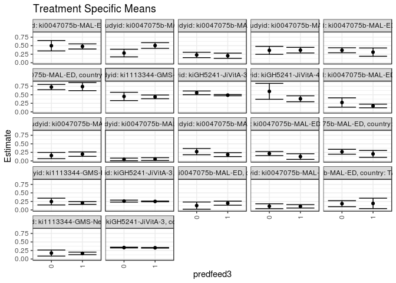

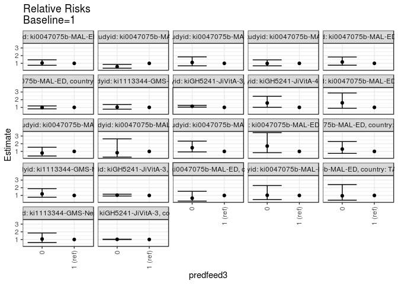

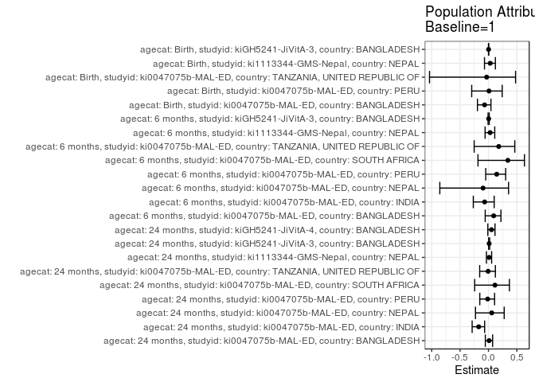

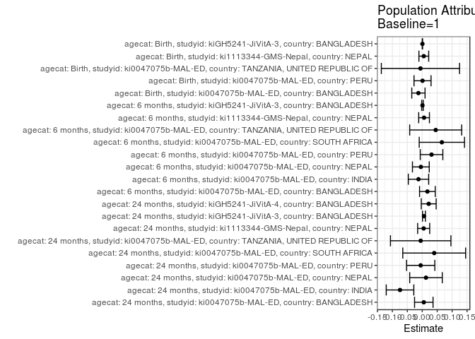

## Results Table

### Parameter: TSM

| agecat | studyid | country | intervention_level | baseline_level | estimate | ci_lower | ci_upper |
| --- | --- | --- | --- | --- | --- | --- | --- |
| Birth | ki0047075b-MAL-ED | BANGLADESH | 1 | NA | 0.1988636 | 0.1397572 | 0.2579701 |
| Birth | ki0047075b-MAL-ED | BANGLADESH | 0 | NA | 0.1282051 | 0.0230361 | 0.2333742 |
| Birth | ki0047075b-MAL-ED | PERU | 1 | NA | 0.1066667 | 0.0571559 | 0.1561774 |
| Birth | ki0047075b-MAL-ED | PERU | 0 | NA | 0.1095890 | 0.0377697 | 0.1814084 |
| Birth | ki0047075b-MAL-ED | TANZANIA, UNITED REPUBLIC OF | 1 | NA | 0.1923077 | 0.0400700 | 0.3445454 |
| Birth | ki0047075b-MAL-ED | TANZANIA, UNITED REPUBLIC OF | 0 | NA | 0.1842105 | 0.0966261 | 0.2717950 |
| Birth | ki1113344-GMS-Nepal | NEPAL | 1 | NA | 0.1651124 | 0.1276382 | 0.2025866 |
| Birth | ki1113344-GMS-Nepal | NEPAL | 0 | NA | 0.1749633 | 0.0863299 | 0.2635967 |
| Birth | kiGH5241-JiVitA-3 | BANGLADESH | 1 | NA | 0.3294885 | 0.3203205 | 0.3386564 |
| Birth | kiGH5241-JiVitA-3 | BANGLADESH | 0 | NA | 0.3353412 | 0.3244624 | 0.3462200 |
| 6 months | ki0047075b-MAL-ED | BANGLADESH | 1 | NA | 0.1715939 | 0.1178456 | 0.2253422 |
| 6 months | ki0047075b-MAL-ED | BANGLADESH | 0 | NA | 0.2730183 | 0.1363265 | 0.4097100 |
| 6 months | ki0047075b-MAL-ED | INDIA | 1 | NA | 0.1982917 | 0.1333591 | 0.2632243 |
| 6 months | ki0047075b-MAL-ED | INDIA | 0 | NA | 0.1566336 | 0.0656282 | 0.2476390 |
| 6 months | ki0047075b-MAL-ED | NEPAL | 1 | NA | 0.0530973 | 0.0116634 | 0.0945313 |
| 6 months | ki0047075b-MAL-ED | NEPAL | 0 | NA | 0.0438597 | 0.0061851 | 0.0815342 |
| 6 months | ki0047075b-MAL-ED | PERU | 1 | NA | 0.1836984 | 0.1261117 | 0.2412851 |
| 6 months | ki0047075b-MAL-ED | PERU | 0 | NA | 0.2712696 | 0.1802590 | 0.3622801 |
| 6 months | ki0047075b-MAL-ED | SOUTH AFRICA | 1 | NA | 0.1269841 | 0.0445978 | 0.2093705 |
| 6 months | ki0047075b-MAL-ED | SOUTH AFRICA | 0 | NA | 0.2154696 | 0.1554493 | 0.2754900 |
| 6 months | ki0047075b-MAL-ED | TANZANIA, UNITED REPUBLIC OF | 1 | NA | 0.2049374 | 0.1042771 | 0.3055976 |
| 6 months | ki0047075b-MAL-ED | TANZANIA, UNITED REPUBLIC OF | 0 | NA | 0.2672786 | 0.1954844 | 0.3390729 |
| 6 months | ki1113344-GMS-Nepal | NEPAL | 1 | NA | 0.2047843 | 0.1634227 | 0.2461459 |
| 6 months | ki1113344-GMS-Nepal | NEPAL | 0 | NA | 0.2460556 | 0.1471406 | 0.3449706 |
| 6 months | kiGH5241-JiVitA-3 | BANGLADESH | 1 | NA | 0.2500899 | 0.2393069 | 0.2608730 |
| 6 months | kiGH5241-JiVitA-3 | BANGLADESH | 0 | NA | 0.2589114 | 0.2299367 | 0.2878860 |
| 24 months | ki0047075b-MAL-ED | BANGLADESH | 1 | NA | 0.4777535 | 0.4024696 | 0.5530374 |
| 24 months | ki0047075b-MAL-ED | BANGLADESH | 0 | NA | 0.4986241 | 0.3458902 | 0.6513580 |
| 24 months | ki0047075b-MAL-ED | INDIA | 1 | NA | 0.5050702 | 0.4215442 | 0.5885962 |
| 24 months | ki0047075b-MAL-ED | INDIA | 0 | NA | 0.2838012 | 0.1720307 | 0.3955716 |
| 24 months | ki0047075b-MAL-ED | NEPAL | 1 | NA | 0.2056681 | 0.1296513 | 0.2816850 |
| 24 months | ki0047075b-MAL-ED | NEPAL | 0 | NA | 0.2288106 | 0.1498998 | 0.3077215 |
| 24 months | ki0047075b-MAL-ED | PERU | 1 | NA | 0.3688759 | 0.2869712 | 0.4507805 |
| 24 months | ki0047075b-MAL-ED | PERU | 0 | NA | 0.3635033 | 0.2472807 | 0.4797260 |
| 24 months | ki0047075b-MAL-ED | SOUTH AFRICA | 1 | NA | 0.3108694 | 0.1895776 | 0.4321613 |
| 24 months | ki0047075b-MAL-ED | SOUTH AFRICA | 0 | NA | 0.3654175 | 0.2921004 | 0.4387346 |
| 24 months | ki0047075b-MAL-ED | TANZANIA, UNITED REPUBLIC OF | 1 | NA | 0.7389262 | 0.6200036 | 0.8578488 |
| 24 months | ki0047075b-MAL-ED | TANZANIA, UNITED REPUBLIC OF | 0 | NA | 0.7251316 | 0.6478884 | 0.8023748 |
| 24 months | ki1113344-GMS-Nepal | NEPAL | 1 | NA | 0.4379380 | 0.3838374 | 0.4920387 |
| 24 months | ki1113344-GMS-Nepal | NEPAL | 0 | NA | 0.4503936 | 0.3289351 | 0.5718521 |
| 24 months | kiGH5241-JiVitA-3 | BANGLADESH | 1 | NA | 0.4881091 | 0.4705299 | 0.5056883 |
| 24 months | kiGH5241-JiVitA-3 | BANGLADESH | 0 | NA | 0.5559987 | 0.5021689 | 0.6098285 |
| 24 months | kiGH5241-JiVitA-4 | BANGLADESH | 1 | NA | 0.3823529 | 0.2957347 | 0.4689712 |
| 24 months | kiGH5241-JiVitA-4 | BANGLADESH | 0 | NA | 0.6000000 | 0.3670443 | 0.8329557 |

### Parameter: E(Y)

| agecat | studyid | country | intervention_level | baseline_level | estimate | ci_lower | ci_upper |
| --- | --- | --- | --- | --- | --- | --- | --- |
| Birth | ki0047075b-MAL-ED | BANGLADESH | NA | NA | 0.1860465 | 0.1339088 | 0.2381842 |
| Birth | ki0047075b-MAL-ED | PERU | NA | NA | 0.1076233 | 0.0668572 | 0.1483894 |
| Birth | ki0047075b-MAL-ED | TANZANIA, UNITED REPUBLIC OF | NA | NA | 0.1862745 | 0.1103463 | 0.2622027 |
| Birth | ki1113344-GMS-Nepal | NEPAL | NA | NA | 0.1703057 | 0.1358418 | 0.2047695 |
| Birth | kiGH5241-JiVitA-3 | BANGLADESH | NA | NA | 0.3300693 | 0.3209240 | 0.3392146 |
| 6 months | ki0047075b-MAL-ED | BANGLADESH | NA | NA | 0.1888412 | 0.1384789 | 0.2392035 |
| 6 months | ki0047075b-MAL-ED | INDIA | NA | NA | 0.1857143 | 0.1329930 | 0.2384356 |
| 6 months | ki0047075b-MAL-ED | NEPAL | NA | NA | 0.0484582 | 0.0204625 | 0.0764538 |
| 6 months | ki0047075b-MAL-ED | PERU | NA | NA | 0.2148148 | 0.1657364 | 0.2638932 |
| 6 months | ki0047075b-MAL-ED | SOUTH AFRICA | NA | NA | 0.1926230 | 0.1430395 | 0.2422064 |
| 6 months | ki0047075b-MAL-ED | TANZANIA, UNITED REPUBLIC OF | NA | NA | 0.2500000 | 0.1915738 | 0.3084262 |
| 6 months | ki1113344-GMS-Nepal | NEPAL | NA | NA | 0.2108844 | 0.1727677 | 0.2490010 |
| 6 months | kiGH5241-JiVitA-3 | BANGLADESH | NA | NA | 0.2508576 | 0.2404565 | 0.2612588 |
| 24 months | ki0047075b-MAL-ED | BANGLADESH | NA | NA | 0.4829268 | 0.4143544 | 0.5514993 |
| 24 months | ki0047075b-MAL-ED | INDIA | NA | NA | 0.4306931 | 0.3622377 | 0.4991484 |
| 24 months | ki0047075b-MAL-ED | NEPAL | NA | NA | 0.2181818 | 0.1634817 | 0.2728819 |
| 24 months | ki0047075b-MAL-ED | PERU | NA | NA | 0.3636364 | 0.2964623 | 0.4308104 |
| 24 months | ki0047075b-MAL-ED | SOUTH AFRICA | NA | NA | 0.3508772 | 0.2887937 | 0.4129607 |
| 24 months | ki0047075b-MAL-ED | TANZANIA, UNITED REPUBLIC OF | NA | NA | 0.7336957 | 0.6696530 | 0.7977384 |
| 24 months | ki1113344-GMS-Nepal | NEPAL | NA | NA | 0.4427083 | 0.3929634 | 0.4924533 |
| 24 months | kiGH5241-JiVitA-3 | BANGLADESH | NA | NA | 0.4938170 | 0.4765272 | 0.5111067 |
| 24 months | kiGH5241-JiVitA-4 | BANGLADESH | NA | NA | 0.4039735 | 0.3218653 | 0.4860818 |

### Parameter: RR

| agecat | studyid | country | intervention_level | baseline_level | estimate | ci_lower | ci_upper |
| --- | --- | --- | --- | --- | --- | --- | --- |
| Birth | ki0047075b-MAL-ED | BANGLADESH | 1 | 1 | 1.0000000 | 1.0000000 | 1.0000000 |
| Birth | ki0047075b-MAL-ED | BANGLADESH | 0 | 1 | 0.6446886 | 0.2694179 | 1.5426722 |
| Birth | ki0047075b-MAL-ED | PERU | 1 | 1 | 1.0000000 | 1.0000000 | 1.0000000 |
| Birth | ki0047075b-MAL-ED | PERU | 0 | 1 | 1.0273973 | 0.4602209 | 2.2935618 |
| Birth | ki0047075b-MAL-ED | TANZANIA, UNITED REPUBLIC OF | 1 | 1 | 1.0000000 | 1.0000000 | 1.0000000 |
| Birth | ki0047075b-MAL-ED | TANZANIA, UNITED REPUBLIC OF | 0 | 1 | 0.9578947 | 0.3804270 | 2.4119274 |
| Birth | ki1113344-GMS-Nepal | NEPAL | 1 | 1 | 1.0000000 | 1.0000000 | 1.0000000 |
| Birth | ki1113344-GMS-Nepal | NEPAL | 0 | 1 | 1.0596619 | 0.6076659 | 1.8478629 |
| Birth | kiGH5241-JiVitA-3 | BANGLADESH | 1 | 1 | 1.0000000 | 1.0000000 | 1.0000000 |
| Birth | kiGH5241-JiVitA-3 | BANGLADESH | 0 | 1 | 1.0177631 | 0.9981966 | 1.0377131 |
| 6 months | ki0047075b-MAL-ED | BANGLADESH | 1 | 1 | 1.0000000 | 1.0000000 | 1.0000000 |
| 6 months | ki0047075b-MAL-ED | BANGLADESH | 0 | 1 | 1.5910721 | 0.8812890 | 2.8725089 |
| 6 months | ki0047075b-MAL-ED | INDIA | 1 | 1 | 1.0000000 | 1.0000000 | 1.0000000 |
| 6 months | ki0047075b-MAL-ED | INDIA | 0 | 1 | 0.7899153 | 0.4039008 | 1.5448500 |
| 6 months | ki0047075b-MAL-ED | NEPAL | 1 | 1 | 1.0000000 | 1.0000000 | 1.0000000 |
| 6 months | ki0047075b-MAL-ED | NEPAL | 0 | 1 | 0.8260234 | 0.2588158 | 2.6362948 |
| 6 months | ki0047075b-MAL-ED | PERU | 1 | 1 | 1.0000000 | 1.0000000 | 1.0000000 |
| 6 months | ki0047075b-MAL-ED | PERU | 0 | 1 | 1.4767115 | 0.9332136 | 2.3367391 |
| 6 months | ki0047075b-MAL-ED | SOUTH AFRICA | 1 | 1 | 1.0000000 | 1.0000000 | 1.0000000 |
| 6 months | ki0047075b-MAL-ED | SOUTH AFRICA | 0 | 1 | 1.6968232 | 0.8375239 | 3.4377634 |
| 6 months | ki0047075b-MAL-ED | TANZANIA, UNITED REPUBLIC OF | 1 | 1 | 1.0000000 | 1.0000000 | 1.0000000 |
| 6 months | ki0047075b-MAL-ED | TANZANIA, UNITED REPUBLIC OF | 0 | 1 | 1.3041967 | 0.7449596 | 2.2832499 |
| 6 months | ki1113344-GMS-Nepal | NEPAL | 1 | 1 | 1.0000000 | 1.0000000 | 1.0000000 |
| 6 months | ki1113344-GMS-Nepal | NEPAL | 0 | 1 | 1.2015353 | 0.7659772 | 1.8847652 |
| 6 months | kiGH5241-JiVitA-3 | BANGLADESH | 1 | 1 | 1.0000000 | 1.0000000 | 1.0000000 |
| 6 months | kiGH5241-JiVitA-3 | BANGLADESH | 0 | 1 | 1.0352730 | 0.9220388 | 1.1624134 |
| 24 months | ki0047075b-MAL-ED | BANGLADESH | 1 | 1 | 1.0000000 | 1.0000000 | 1.0000000 |
| 24 months | ki0047075b-MAL-ED | BANGLADESH | 0 | 1 | 1.0436848 | 0.7464279 | 1.4593211 |
| 24 months | ki0047075b-MAL-ED | INDIA | 1 | 1 | 1.0000000 | 1.0000000 | 1.0000000 |
| 24 months | ki0047075b-MAL-ED | INDIA | 0 | 1 | 0.5619044 | 0.3663003 | 0.8619608 |
| 24 months | ki0047075b-MAL-ED | NEPAL | 1 | 1 | 1.0000000 | 1.0000000 | 1.0000000 |
| 24 months | ki0047075b-MAL-ED | NEPAL | 0 | 1 | 1.1125236 | 0.6724771 | 1.8405219 |
| 24 months | ki0047075b-MAL-ED | PERU | 1 | 1 | 1.0000000 | 1.0000000 | 1.0000000 |
| 24 months | ki0047075b-MAL-ED | PERU | 0 | 1 | 0.9854354 | 0.6711678 | 1.4468556 |
| 24 months | ki0047075b-MAL-ED | SOUTH AFRICA | 1 | 1 | 1.0000000 | 1.0000000 | 1.0000000 |
| 24 months | ki0047075b-MAL-ED | SOUTH AFRICA | 0 | 1 | 1.1754694 | 0.7577227 | 1.8235278 |
| 24 months | ki0047075b-MAL-ED | TANZANIA, UNITED REPUBLIC OF | 1 | 1 | 1.0000000 | 1.0000000 | 1.0000000 |
| 24 months | ki0047075b-MAL-ED | TANZANIA, UNITED REPUBLIC OF | 0 | 1 | 0.9813316 | 0.8092656 | 1.1899823 |
| 24 months | ki1113344-GMS-Nepal | NEPAL | 1 | 1 | 1.0000000 | 1.0000000 | 1.0000000 |
| 24 months | ki1113344-GMS-Nepal | NEPAL | 0 | 1 | 1.0284414 | 0.7686534 | 1.3760320 |
| 24 months | kiGH5241-JiVitA-3 | BANGLADESH | 1 | 1 | 1.0000000 | 1.0000000 | 1.0000000 |
| 24 months | kiGH5241-JiVitA-3 | BANGLADESH | 0 | 1 | 1.1390868 | 1.0314281 | 1.2579828 |
| 24 months | kiGH5241-JiVitA-4 | BANGLADESH | 1 | 1 | 1.0000000 | 1.0000000 | 1.0000000 |
| 24 months | kiGH5241-JiVitA-4 | BANGLADESH | 0 | 1 | 1.5692308 | 1.0057767 | 2.4483420 |

### Parameter: PAR

| agecat | studyid | country | intervention_level | baseline_level | estimate | ci_lower | ci_upper |
| --- | --- | --- | --- | --- | --- | --- | --- |
| Birth | ki0047075b-MAL-ED | BANGLADESH | 1 | NA | -0.0128171 | -0.0350027 | 0.0093685 |
| Birth | ki0047075b-MAL-ED | PERU | 1 | NA | 0.0009567 | -0.0275995 | 0.0295128 |
| Birth | ki0047075b-MAL-ED | TANZANIA, UNITED REPUBLIC OF | 1 | NA | -0.0060332 | -0.1368996 | 0.1248333 |
| Birth | ki1113344-GMS-Nepal | NEPAL | 1 | NA | 0.0051933 | -0.0111346 | 0.0215211 |
| Birth | kiGH5241-JiVitA-3 | BANGLADESH | 1 | NA | 0.0005808 | -0.0000220 | 0.0011837 |
| 6 months | ki0047075b-MAL-ED | BANGLADESH | 1 | NA | 0.0172473 | -0.0089705 | 0.0434651 |
| 6 months | ki0047075b-MAL-ED | INDIA | 1 | NA | -0.0125774 | -0.0466738 | 0.0215190 |
| 6 months | ki0047075b-MAL-ED | NEPAL | 1 | NA | -0.0046392 | -0.0327696 | 0.0234912 |
| 6 months | ki0047075b-MAL-ED | PERU | 1 | NA | 0.0311164 | -0.0066887 | 0.0689214 |
| 6 months | ki0047075b-MAL-ED | SOUTH AFRICA | 1 | NA | 0.0656388 | -0.0101306 | 0.1414083 |
| 6 months | ki0047075b-MAL-ED | TANZANIA, UNITED REPUBLIC OF | 1 | NA | 0.0450626 | -0.0420119 | 0.1321372 |
| 6 months | ki1113344-GMS-Nepal | NEPAL | 1 | NA | 0.0061000 | -0.0118435 | 0.0240435 |
| 6 months | kiGH5241-JiVitA-3 | BANGLADESH | 1 | NA | 0.0007677 | -0.0018165 | 0.0033519 |
| 24 months | ki0047075b-MAL-ED | BANGLADESH | 1 | NA | 0.0051733 | -0.0257699 | 0.0361165 |
| 24 months | ki0047075b-MAL-ED | INDIA | 1 | NA | -0.0743771 | -0.1204727 | -0.0282815 |
| 24 months | ki0047075b-MAL-ED | NEPAL | 1 | NA | 0.0125137 | -0.0419719 | 0.0669993 |
| 24 months | ki0047075b-MAL-ED | PERU | 1 | NA | -0.0052395 | -0.0525054 | 0.0420263 |
| 24 months | ki0047075b-MAL-ED | SOUTH AFRICA | 1 | NA | 0.0400078 | -0.0651644 | 0.1451800 |
| 24 months | ki0047075b-MAL-ED | TANZANIA, UNITED REPUBLIC OF | 1 | NA | -0.0052305 | -0.1064124 | 0.0959514 |
| 24 months | ki1113344-GMS-Nepal | NEPAL | 1 | NA | 0.0047703 | -0.0153992 | 0.0249398 |
| 24 months | kiGH5241-JiVitA-3 | BANGLADESH | 1 | NA | 0.0057079 | 0.0009065 | 0.0105092 |
| 24 months | kiGH5241-JiVitA-4 | BANGLADESH | 1 | NA | 0.0216206 | -0.0032699 | 0.0465111 |

### Parameter: PAF

| agecat | studyid | country | intervention_level | baseline_level | estimate | ci_lower | ci_upper |
| --- | --- | --- | --- | --- | --- | --- | --- |
| Birth | ki0047075b-MAL-ED | BANGLADESH | 1 | NA | -0.0688920 | -0.1941495 | 0.0432269 |
| Birth | ki0047075b-MAL-ED | PERU | 1 | NA | 0.0088889 | -0.2953346 | 0.2416622 |
| Birth | ki0047075b-MAL-ED | TANZANIA, UNITED REPUBLIC OF | 1 | NA | -0.0323887 | -1.0387102 | 0.4772056 |
| Birth | ki1113344-GMS-Nepal | NEPAL | 1 | NA | 0.0304938 | -0.0701969 | 0.1217109 |
| Birth | kiGH5241-JiVitA-3 | BANGLADESH | 1 | NA | 0.0017597 | -0.0000693 | 0.0035854 |
| 6 months | ki0047075b-MAL-ED | BANGLADESH | 1 | NA | 0.0913323 | -0.0575583 | 0.2192611 |
| 6 months | ki0047075b-MAL-ED | INDIA | 1 | NA | -0.0677245 | -0.2675038 | 0.1005664 |
| 6 months | ki0047075b-MAL-ED | NEPAL | 1 | NA | -0.0957361 | -0.8572107 | 0.3535264 |
| 6 months | ki0047075b-MAL-ED | PERU | 1 | NA | 0.1448521 | -0.0486554 | 0.3026519 |
| 6 months | ki0047075b-MAL-ED | SOUTH AFRICA | 1 | NA | 0.3407633 | -0.1850142 | 0.6332592 |
| 6 months | ki0047075b-MAL-ED | TANZANIA, UNITED REPUBLIC OF | 1 | NA | 0.1802506 | -0.2521645 | 0.4633380 |
| 6 months | ki1113344-GMS-Nepal | NEPAL | 1 | NA | 0.0289260 | -0.0599079 | 0.1103145 |
| 6 months | kiGH5241-JiVitA-3 | BANGLADESH | 1 | NA | 0.0030603 | -0.0072988 | 0.0133128 |
| 24 months | ki0047075b-MAL-ED | BANGLADESH | 1 | NA | 0.0107124 | -0.0555048 | 0.0727755 |
| 24 months | ki0047075b-MAL-ED | INDIA | 1 | NA | -0.1726917 | -0.2877854 | -0.0678843 |
| 24 months | ki0047075b-MAL-ED | NEPAL | 1 | NA | 0.0573545 | -0.2285419 | 0.2767194 |
| 24 months | ki0047075b-MAL-ED | PERU | 1 | NA | -0.0144087 | -0.1531337 | 0.1076274 |
| 24 months | ki0047075b-MAL-ED | SOUTH AFRICA | 1 | NA | 0.1140222 | -0.2431689 | 0.3685840 |
| 24 months | ki0047075b-MAL-ED | TANZANIA, UNITED REPUBLIC OF | 1 | NA | -0.0071290 | -0.1549367 | 0.1217623 |
| 24 months | ki1113344-GMS-Nepal | NEPAL | 1 | NA | 0.0107753 | -0.0358951 | 0.0553430 |
| 24 months | kiGH5241-JiVitA-3 | BANGLADESH | 1 | NA | 0.0115586 | 0.0018111 | 0.0212110 |
| 24 months | kiGH5241-JiVitA-4 | BANGLADESH | 1 | NA | 0.0535198 | -0.0115565 | 0.1144095 |